# Risk Factor Analysis

## Outcome Variable

**Outcome Variable:** ever_co

## Predictor Variables

**Intervention Variable:** single

**Adjustment Set:**

unadjusted

## Stratifying Variables

The analysis was stratified on these variable(s):

- agecat
- studyid
- country

## Data Summary

| agecat | studyid | country | single | ever_co | n_cell | n | outcome_variable |
| --- | --- | --- | --- | --- | --- | --- | --- |
| 0-24 months | ki0047075b-MAL-ED | BANGLADESH | 0 | 0 | 224 | 263 | ever_co |
| 0-24 months | ki0047075b-MAL-ED | BANGLADESH | 0 | 1 | 39 | 263 | ever_co |
| 0-24 months | ki0047075b-MAL-ED | BANGLADESH | 1 | 0 | 0 | 263 | ever_co |
| 0-24 months | ki0047075b-MAL-ED | BANGLADESH | 1 | 1 | 0 | 263 | ever_co |
| 0-24 months | ki0047075b-MAL-ED | BRAZIL | 0 | 0 | 196 | 233 | ever_co |
| 0-24 months | ki0047075b-MAL-ED | BRAZIL | 0 | 1 | 1 | 233 | ever_co |
| 0-24 months | ki0047075b-MAL-ED | BRAZIL | 1 | 0 | 34 | 233 | ever_co |
| 0-24 months | ki0047075b-MAL-ED | BRAZIL | 1 | 1 | 2 | 233 | ever_co |
| 0-24 months | ki0047075b-MAL-ED | INDIA | 0 | 0 | 196 | 249 | ever_co |
| 0-24 months | ki0047075b-MAL-ED | INDIA | 0 | 1 | 53 | 249 | ever_co |
| 0-24 months | ki0047075b-MAL-ED | INDIA | 1 | 0 | 0 | 249 | ever_co |
| 0-24 months | ki0047075b-MAL-ED | INDIA | 1 | 1 | 0 | 249 | ever_co |
| 0-24 months | ki0047075b-MAL-ED | NEPAL | 0 | 0 | 218 | 240 | ever_co |
| 0-24 months | ki0047075b-MAL-ED | NEPAL | 0 | 1 | 22 | 240 | ever_co |
| 0-24 months | ki0047075b-MAL-ED | NEPAL | 1 | 0 | 0 | 240 | ever_co |
| 0-24 months | ki0047075b-MAL-ED | NEPAL | 1 | 1 | 0 | 240 | ever_co |
| 0-24 months | ki0047075b-MAL-ED | PERU | 0 | 0 | 260 | 302 | ever_co |
| 0-24 months | ki0047075b-MAL-ED | PERU | 0 | 1 | 8 | 302 | ever_co |
| 0-24 months | ki0047075b-MAL-ED | PERU | 1 | 0 | 30 | 302 | ever_co |
| 0-24 months | ki0047075b-MAL-ED | PERU | 1 | 1 | 4 | 302 | ever_co |
| 0-24 months | ki0047075b-MAL-ED | SOUTH AFRICA | 0 | 0 | 165 | 312 | ever_co |
| 0-24 months | ki0047075b-MAL-ED | SOUTH AFRICA | 0 | 1 | 11 | 312 | ever_co |
| 0-24 months | ki0047075b-MAL-ED | SOUTH AFRICA | 1 | 0 | 124 | 312 | ever_co |
| 0-24 months | ki0047075b-MAL-ED | SOUTH AFRICA | 1 | 1 | 12 | 312 | ever_co |
| 0-24 months | ki0047075b-MAL-ED | TANZANIA, UNITED REPUBLIC OF | 0 | 0 | 229 | 261 | ever_co |
| 0-24 months | ki0047075b-MAL-ED | TANZANIA, UNITED REPUBLIC OF | 0 | 1 | 22 | 261 | ever_co |
| 0-24 months | ki0047075b-MAL-ED | TANZANIA, UNITED REPUBLIC OF | 1 | 0 | 9 | 261 | ever_co |
| 0-24 months | ki0047075b-MAL-ED | TANZANIA, UNITED REPUBLIC OF | 1 | 1 | 1 | 261 | ever_co |
| 0-24 months | ki1066203-TanzaniaChild2 | TANZANIA, UNITED REPUBLIC OF | 0 | 0 | 2039 | 2375 | ever_co |
| 0-24 months | ki1066203-TanzaniaChild2 | TANZANIA, UNITED REPUBLIC OF | 0 | 1 | 112 | 2375 | ever_co |

[output cut: 150 more lines]

The following strata were considered:

- agecat: 0-24 months, studyid: ki0047075b-MAL-ED, country: BANGLADESH
- agecat: 0-24 months, studyid: ki0047075b-MAL-ED, country: BRAZIL
- agecat: 0-24 months, studyid: ki0047075b-MAL-ED, country: INDIA
- agecat: 0-24 months, studyid: ki0047075b-MAL-ED, country: NEPAL
- agecat: 0-24 months, studyid: ki0047075b-MAL-ED, country: PERU
- agecat: 0-24 months, studyid: ki0047075b-MAL-ED, country: SOUTH AFRICA
- agecat: 0-24 months, studyid: ki0047075b-MAL-ED, country: TANZANIA, UNITED REPUBLIC OF
- agecat: 0-24 months, studyid: ki1066203-TanzaniaChild2, country: TANZANIA, UNITED REPUBLIC OF
- agecat: 0-24 months, studyid: ki1112895-Guatemala BSC, country: GUATEMALA
- agecat: 0-24 months, studyid: ki1119695-PROBIT, country: BELARUS
- agecat: 0-24 months, studyid: ki1126311-ZVITAMBO, country: ZIMBABWE
- agecat: 0-24 months, studyid: ki1135781-COHORTS, country: GUATEMALA
- agecat: 0-24 months, studyid: ki1135781-COHORTS, country: INDIA
- agecat: 0-24 months, studyid: ki1135781-COHORTS, country: PHILIPPINES
- agecat: 0-24 months, studyid: kiGH5241-JiVitA-4, country: BANGLADESH
- agecat: 0-6 months, studyid: ki0047075b-MAL-ED, country: BANGLADESH
- agecat: 0-6 months, studyid: ki0047075b-MAL-ED, country: BRAZIL
- agecat: 0-6 months, studyid: ki0047075b-MAL-ED, country: INDIA
- agecat: 0-6 months, studyid: ki0047075b-MAL-ED, country: NEPAL
- agecat: 0-6 months, studyid: ki0047075b-MAL-ED, country: PERU
- agecat: 0-6 months, studyid: ki0047075b-MAL-ED, country: SOUTH AFRICA
- agecat: 0-6 months, studyid: ki0047075b-MAL-ED, country: TANZANIA, UNITED REPUBLIC OF
- agecat: 0-6 months, studyid: ki1066203-TanzaniaChild2, country: TANZANIA, UNITED REPUBLIC OF
- agecat: 0-6 months, studyid: ki1112895-Guatemala BSC, country: GUATEMALA
- agecat: 0-6 months, studyid: ki1119695-PROBIT, country: BELARUS
- agecat: 0-6 months, studyid: ki1126311-ZVITAMBO, country: ZIMBABWE
- agecat: 0-6 months, studyid: ki1135781-COHORTS, country: GUATEMALA
- agecat: 0-6 months, studyid: ki1135781-COHORTS, country: INDIA
- agecat: 0-6 months, studyid: ki1135781-COHORTS, country: PHILIPPINES
- agecat: 0-6 months, studyid: kiGH5241-JiVitA-4, country: BANGLADESH
- agecat: 6-24 months, studyid: ki0047075b-MAL-ED, country: BANGLADESH
- agecat: 6-24 months, studyid: ki0047075b-MAL-ED, country: BRAZIL
- agecat: 6-24 months, studyid: ki0047075b-MAL-ED, country: INDIA
- agecat: 6-24 months, studyid: ki0047075b-MAL-ED, country: NEPAL
- agecat: 6-24 months, studyid: ki0047075b-MAL-ED, country: PERU
- agecat: 6-24 months, studyid: ki0047075b-MAL-ED, country: SOUTH AFRICA
- agecat: 6-24 months, studyid: ki0047075b-MAL-ED, country: TANZANIA, UNITED REPUBLIC OF
- agecat: 6-24 months, studyid: ki1066203-TanzaniaChild2, country: TANZANIA, UNITED REPUBLIC OF
- agecat: 6-24 months, studyid: ki1112895-Guatemala BSC, country: GUATEMALA
- agecat: 6-24 months, studyid: ki1119695-PROBIT, country: BELARUS
- agecat: 6-24 months, studyid: ki1126311-ZVITAMBO, country: ZIMBABWE
- agecat: 6-24 months, studyid: ki1135781-COHORTS, country: GUATEMALA
- agecat: 6-24 months, studyid: ki1135781-COHORTS, country: INDIA
- agecat: 6-24 months, studyid: ki1135781-COHORTS, country: PHILIPPINES
- agecat: 6-24 months, studyid: kiGH5241-JiVitA-4, country: BANGLADESH

### Dropped Strata

Some strata were dropped due to rare outcomes:

- agecat: 0-24 months, studyid: ki0047075b-MAL-ED, country: BANGLADESH
- agecat: 0-24 months, studyid: ki0047075b-MAL-ED, country: BRAZIL
- agecat: 0-24 months, studyid: ki0047075b-MAL-ED, country: INDIA
- agecat: 0-24 months, studyid: ki0047075b-MAL-ED, country: NEPAL
- agecat: 0-24 months, studyid: ki0047075b-MAL-ED, country: PERU
- agecat: 0-24 months, studyid: ki0047075b-MAL-ED, country: TANZANIA, UNITED REPUBLIC OF
- agecat: 0-24 months, studyid: ki1112895-Guatemala BSC, country: GUATEMALA
- agecat: 0-24 months, studyid: ki1119695-PROBIT, country: BELARUS
- agecat: 0-24 months, studyid: ki1135781-COHORTS, country: INDIA
- agecat: 0-24 months, studyid: kiGH5241-JiVitA-4, country: BANGLADESH
- agecat: 0-6 months, studyid: ki0047075b-MAL-ED, country: BANGLADESH
- agecat: 0-6 months, studyid: ki0047075b-MAL-ED, country: BRAZIL
- agecat: 0-6 months, studyid: ki0047075b-MAL-ED, country: INDIA
- agecat: 0-6 months, studyid: ki0047075b-MAL-ED, country: NEPAL
- agecat: 0-6 months, studyid: ki0047075b-MAL-ED, country: PERU
- agecat: 0-6 months, studyid: ki0047075b-MAL-ED, country: SOUTH AFRICA
- agecat: 0-6 months, studyid: ki0047075b-MAL-ED, country: TANZANIA, UNITED REPUBLIC OF
- agecat: 0-6 months, studyid: ki1066203-TanzaniaChild2, country: TANZANIA, UNITED REPUBLIC OF
- agecat: 0-6 months, studyid: ki1112895-Guatemala BSC, country: GUATEMALA
- agecat: 0-6 months, studyid: ki1119695-PROBIT, country: BELARUS
- agecat: 0-6 months, studyid: ki1135781-COHORTS, country: GUATEMALA
- agecat: 0-6 months, studyid: ki1135781-COHORTS, country: INDIA
- agecat: 0-6 months, studyid: kiGH5241-JiVitA-4, country: BANGLADESH
- agecat: 6-24 months, studyid: ki0047075b-MAL-ED, country: BANGLADESH
- agecat: 6-24 months, studyid: ki0047075b-MAL-ED, country: BRAZIL
- agecat: 6-24 months, studyid: ki0047075b-MAL-ED, country: INDIA
- agecat: 6-24 months, studyid: ki0047075b-MAL-ED, country: NEPAL
- agecat: 6-24 months, studyid: ki0047075b-MAL-ED, country: PERU
- agecat: 6-24 months, studyid: ki0047075b-MAL-ED, country: TANZANIA, UNITED REPUBLIC OF
- agecat: 6-24 months, studyid: ki1112895-Guatemala BSC, country: GUATEMALA
- agecat: 6-24 months, studyid: ki1119695-PROBIT, country: BELARUS
- agecat: 6-24 months, studyid: ki1135781-COHORTS, country: INDIA
- agecat: 6-24 months, studyid: kiGH5241-JiVitA-4, country: BANGLADESH

## Methods Detail

We’re interested in the causal parameters $E[Y_a]$ for all values of $a \in \mathcal{A}$. These parameters represent the mean outcome if, possibly contrary to fact, we intervened to set all units to have $A=a$. Under the randomization and positivity assumptions, these are identified by the statistical parameters $\psi_a=E_W[E_{Y|A,W}(Y|A=a,W)]$. In addition, we’re interested in the mean of $Y$, $E[Y]$ under no intervention (the observed mean). We will estimate these parameters by using SuperLearner to fit the relevant likelihood factors – $E_{Y|A,W}(Y|A=a,W)$ and $p(A=a|W)$, and then updating our likelihood fit using a joint TMLE.

For unadjusted analyses ($W=\{\}$), initial likelihoods were estimated using Lrnr_glm to estimate the simple $E(Y|A)$ and Lrnr_mean to estimate $p(A)$. For adjusted analyses, a small library containing Lrnr_glmnet, Lrnr_xgboost, and Lrnr_mean was used.

Having estimated these parameters, we will then use the delta method to estimate relative risks and attributable risks relative to a prespecified baseline level of $A$.

# Results Detail

## Results Plots

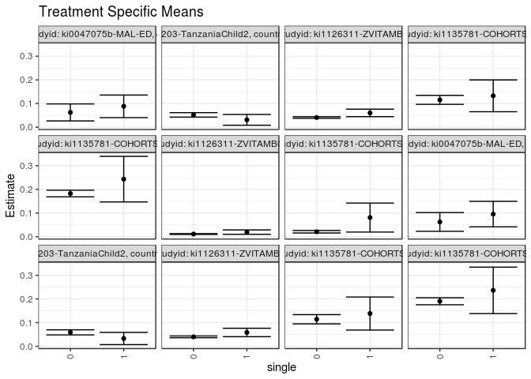

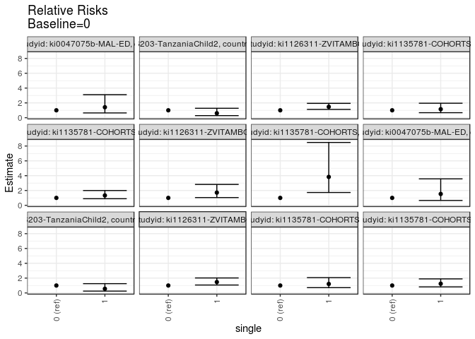

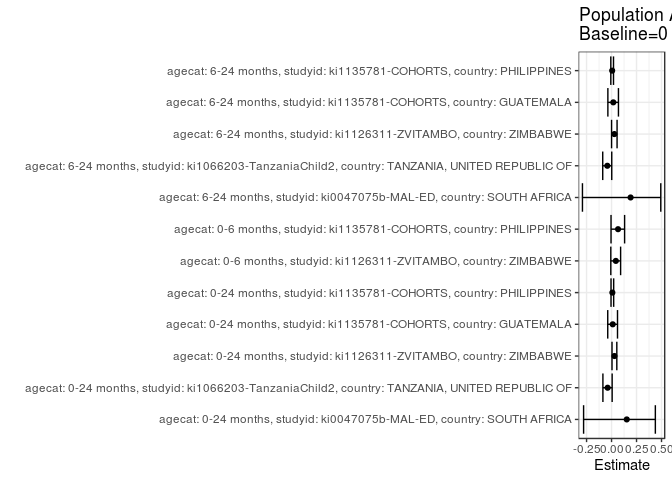

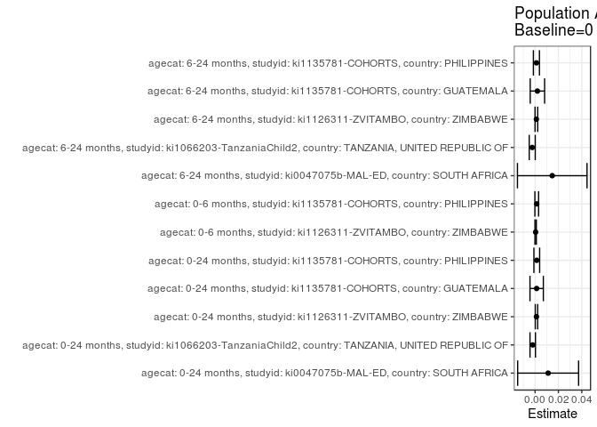

## Results Table

### Parameter: TSM

| agecat | studyid | country | intervention_level | baseline_level | estimate | ci_lower | ci_upper |
| --- | --- | --- | --- | --- | --- | --- | --- |
| 0-24 months | ki0047075b-MAL-ED | SOUTH AFRICA | 0 | NA | 0.0625000 | 0.0266809 | 0.0983191 |
| 0-24 months | ki0047075b-MAL-ED | SOUTH AFRICA | 1 | NA | 0.0882353 | 0.0404892 | 0.1359814 |
| 0-24 months | ki1066203-TanzaniaChild2 | TANZANIA, UNITED REPUBLIC OF | 0 | NA | 0.0520688 | 0.0426781 | 0.0614595 |
| 0-24 months | ki1066203-TanzaniaChild2 | TANZANIA, UNITED REPUBLIC OF | 1 | NA | 0.0312500 | 0.0084599 | 0.0540401 |
| 0-24 months | ki1126311-ZVITAMBO | ZIMBABWE | 0 | NA | 0.0410485 | 0.0376390 | 0.0444580 |
| 0-24 months | ki1126311-ZVITAMBO | ZIMBABWE | 1 | NA | 0.0604333 | 0.0446621 | 0.0762045 |
| 0-24 months | ki1135781-COHORTS | GUATEMALA | 0 | NA | 0.1155596 | 0.0966506 | 0.1344686 |
| 0-24 months | ki1135781-COHORTS | GUATEMALA | 1 | NA | 0.1326531 | 0.0654682 | 0.1998379 |
| 0-24 months | ki1135781-COHORTS | PHILIPPINES | 0 | NA | 0.1825316 | 0.1685394 | 0.1965237 |
| 0-24 months | ki1135781-COHORTS | PHILIPPINES | 1 | NA | 0.2432432 | 0.1469379 | 0.3395486 |
| 0-6 months | ki1126311-ZVITAMBO | ZIMBABWE | 0 | NA | 0.0114516 | 0.0096172 | 0.0132860 |
| 0-6 months | ki1126311-ZVITAMBO | ZIMBABWE | 1 | NA | 0.0196305 | 0.0103906 | 0.0288703 |
| 0-6 months | ki1135781-COHORTS | PHILIPPINES | 0 | NA | 0.0211604 | 0.0159465 | 0.0263744 |
| 0-6 months | ki1135781-COHORTS | PHILIPPINES | 1 | NA | 0.0810811 | 0.0197904 | 0.1423718 |
| 6-24 months | ki0047075b-MAL-ED | SOUTH AFRICA | 0 | NA | 0.0625000 | 0.0228875 | 0.1021125 |
| 6-24 months | ki0047075b-MAL-ED | SOUTH AFRICA | 1 | NA | 0.0956522 | 0.0417937 | 0.1495107 |
| 6-24 months | ki1066203-TanzaniaChild2 | TANZANIA, UNITED REPUBLIC OF | 0 | NA | 0.0588235 | 0.0480079 | 0.0696391 |
| 6-24 months | ki1066203-TanzaniaChild2 | TANZANIA, UNITED REPUBLIC OF | 1 | NA | 0.0327869 | 0.0069796 | 0.0585942 |
| 6-24 months | ki1126311-ZVITAMBO | ZIMBABWE | 0 | NA | 0.0397980 | 0.0359856 | 0.0436104 |
| 6-24 months | ki1126311-ZVITAMBO | ZIMBABWE | 1 | NA | 0.0583832 | 0.0406020 | 0.0761644 |
| 6-24 months | ki1135781-COHORTS | GUATEMALA | 0 | NA | 0.1141732 | 0.0946094 | 0.1337370 |
| 6-24 months | ki1135781-COHORTS | GUATEMALA | 1 | NA | 0.1382979 | 0.0684801 | 0.2081157 |
| 6-24 months | ki1135781-COHORTS | PHILIPPINES | 0 | NA | 0.1902295 | 0.1754280 | 0.2050309 |
| 6-24 months | ki1135781-COHORTS | PHILIPPINES | 1 | NA | 0.2361111 | 0.1379966 | 0.3342257 |

### Parameter: E(Y)

| agecat | studyid | country | intervention_level | baseline_level | estimate | ci_lower | ci_upper |
| --- | --- | --- | --- | --- | --- | --- | --- |
| 0-24 months | ki0047075b-MAL-ED | SOUTH AFRICA | NA | NA | 0.0737179 | 0.0446760 | 0.1027599 |
| 0-24 months | ki1066203-TanzaniaChild2 | TANZANIA, UNITED REPUBLIC OF | NA | NA | 0.0501053 | 0.0413295 | 0.0588811 |
| 0-24 months | ki1126311-ZVITAMBO | ZIMBABWE | NA | NA | 0.0422728 | 0.0389260 | 0.0456196 |
| 0-24 months | ki1135781-COHORTS | GUATEMALA | NA | NA | 0.1169591 | 0.0987457 | 0.1351724 |
| 0-24 months | ki1135781-COHORTS | PHILIPPINES | NA | NA | 0.1840266 | 0.1701694 | 0.1978839 |
| 0-6 months | ki1126311-ZVITAMBO | ZIMBABWE | NA | NA | 0.0119652 | 0.0101504 | 0.0137800 |
| 0-6 months | ki1135781-COHORTS | PHILIPPINES | NA | NA | 0.0226365 | 0.0173166 | 0.0279564 |
| 6-24 months | ki0047075b-MAL-ED | SOUTH AFRICA | NA | NA | 0.0772201 | 0.0446475 | 0.1097927 |
| 6-24 months | ki1066203-TanzaniaChild2 | TANZANIA, UNITED REPUBLIC OF | NA | NA | 0.0564436 | 0.0463321 | 0.0665551 |
| 6-24 months | ki1126311-ZVITAMBO | ZIMBABWE | NA | NA | 0.0409509 | 0.0372078 | 0.0446940 |
| 6-24 months | ki1135781-COHORTS | GUATEMALA | NA | NA | 0.1162162 | 0.0973542 | 0.1350783 |
| 6-24 months | ki1135781-COHORTS | PHILIPPINES | NA | NA | 0.1914203 | 0.1767774 | 0.2060633 |

### Parameter: RR

| agecat | studyid | country | intervention_level | baseline_level | estimate | ci_lower | ci_upper |
| --- | --- | --- | --- | --- | --- | --- | --- |
| 0-24 months | ki0047075b-MAL-ED | SOUTH AFRICA | 0 | 0 | 1.0000000 | 1.0000000 | 1.000000 |
| 0-24 months | ki0047075b-MAL-ED | SOUTH AFRICA | 1 | 0 | 1.4117647 | 0.6418745 | 3.105092 |
| 0-24 months | ki1066203-TanzaniaChild2 | TANZANIA, UNITED REPUBLIC OF | 0 | 0 | 1.0000000 | 1.0000000 | 1.000000 |
| 0-24 months | ki1066203-TanzaniaChild2 | TANZANIA, UNITED REPUBLIC OF | 1 | 0 | 0.6001674 | 0.2831440 | 1.272147 |
| 0-24 months | ki1126311-ZVITAMBO | ZIMBABWE | 0 | 0 | 1.0000000 | 1.0000000 | 1.000000 |
| 0-24 months | ki1126311-ZVITAMBO | ZIMBABWE | 1 | 0 | 1.4722411 | 1.1195393 | 1.936059 |
| 0-24 months | ki1135781-COHORTS | GUATEMALA | 0 | 0 | 1.0000000 | 1.0000000 | 1.000000 |
| 0-24 months | ki1135781-COHORTS | GUATEMALA | 1 | 0 | 1.1479190 | 0.6741541 | 1.954624 |
| 0-24 months | ki1135781-COHORTS | PHILIPPINES | 0 | 0 | 1.0000000 | 1.0000000 | 1.000000 |
| 0-24 months | ki1135781-COHORTS | PHILIPPINES | 1 | 0 | 1.3326092 | 0.8903545 | 1.994540 |
| 0-6 months | ki1126311-ZVITAMBO | ZIMBABWE | 0 | 0 | 1.0000000 | 1.0000000 | 1.000000 |
| 0-6 months | ki1126311-ZVITAMBO | ZIMBABWE | 1 | 0 | 1.7142188 | 1.0426406 | 2.818369 |
| 0-6 months | ki1135781-COHORTS | PHILIPPINES | 0 | 0 | 1.0000000 | 1.0000000 | 1.000000 |
| 0-6 months | ki1135781-COHORTS | PHILIPPINES | 1 | 0 | 3.8317349 | 1.7302287 | 8.485695 |
| 6-24 months | ki0047075b-MAL-ED | SOUTH AFRICA | 0 | 0 | 1.0000000 | 1.0000000 | 1.000000 |
| 6-24 months | ki0047075b-MAL-ED | SOUTH AFRICA | 1 | 0 | 1.5304348 | 0.6555784 | 3.572770 |
| 6-24 months | ki1066203-TanzaniaChild2 | TANZANIA, UNITED REPUBLIC OF | 0 | 0 | 1.0000000 | 1.0000000 | 1.000000 |
| 6-24 months | ki1066203-TanzaniaChild2 | TANZANIA, UNITED REPUBLIC OF | 1 | 0 | 0.5573770 | 0.2483727 | 1.250819 |
| 6-24 months | ki1126311-ZVITAMBO | ZIMBABWE | 0 | 0 | 1.0000000 | 1.0000000 | 1.000000 |
| 6-24 months | ki1126311-ZVITAMBO | ZIMBABWE | 1 | 0 | 1.4669877 | 1.0660297 | 2.018755 |
| 6-24 months | ki1135781-COHORTS | GUATEMALA | 0 | 0 | 1.0000000 | 1.0000000 | 1.000000 |
| 6-24 months | ki1135781-COHORTS | GUATEMALA | 1 | 0 | 1.2112986 | 0.7107524 | 2.064354 |
| 6-24 months | ki1135781-COHORTS | PHILIPPINES | 0 | 0 | 1.0000000 | 1.0000000 | 1.000000 |
| 6-24 months | ki1135781-COHORTS | PHILIPPINES | 1 | 0 | 1.2411911 | 0.8132682 | 1.894277 |

### Parameter: PAR

| agecat | studyid | country | intervention_level | baseline_level | estimate | ci_lower | ci_upper |
| --- | --- | --- | --- | --- | --- | --- | --- |
| 0-24 months | ki0047075b-MAL-ED | SOUTH AFRICA | 0 | NA | 0.0112179 | -0.0148387 | 0.0372746 |
| 0-24 months | ki1066203-TanzaniaChild2 | TANZANIA, UNITED REPUBLIC OF | 0 | NA | -0.0019635 | -0.0043012 | 0.0003741 |
| 0-24 months | ki1126311-ZVITAMBO | ZIMBABWE | 0 | NA | 0.0012243 | 0.0002022 | 0.0022464 |
| 0-24 months | ki1135781-COHORTS | GUATEMALA | 0 | NA | 0.0013995 | -0.0043209 | 0.0071199 |
| 0-24 months | ki1135781-COHORTS | PHILIPPINES | 0 | NA | 0.0014951 | -0.0009610 | 0.0039511 |
| 0-6 months | ki1126311-ZVITAMBO | ZIMBABWE | 0 | NA | 0.0005136 | -0.0000789 | 0.0011061 |
| 0-6 months | ki1135781-COHORTS | PHILIPPINES | 0 | NA | 0.0014761 | -0.0000972 | 0.0030493 |
| 6-24 months | ki0047075b-MAL-ED | SOUTH AFRICA | 0 | NA | 0.0147201 | -0.0150335 | 0.0444737 |
| 6-24 months | ki1066203-TanzaniaChild2 | TANZANIA, UNITED REPUBLIC OF | 0 | NA | -0.0023800 | -0.0049588 | 0.0001989 |
| 6-24 months | ki1126311-ZVITAMBO | ZIMBABWE | 0 | NA | 0.0011528 | 0.0000216 | 0.0022840 |
| 6-24 months | ki1135781-COHORTS | GUATEMALA | 0 | NA | 0.0020430 | -0.0041100 | 0.0081959 |
| 6-24 months | ki1135781-COHORTS | PHILIPPINES | 0 | NA | 0.0011909 | -0.0013988 | 0.0037806 |

### Parameter: PAF

| agecat | studyid | country | intervention_level | baseline_level | estimate | ci_lower | ci_upper |
| --- | --- | --- | --- | --- | --- | --- | --- |
| 0-24 months | ki0047075b-MAL-ED | SOUTH AFRICA | 0 | NA | 0.1521739 | -0.2796753 | 0.4382879 |
| 0-24 months | ki1066203-TanzaniaChild2 | TANZANIA, UNITED REPUBLIC OF | 0 | NA | -0.0391883 | -0.0864337 | 0.0060025 |
| 0-24 months | ki1126311-ZVITAMBO | ZIMBABWE | 0 | NA | 0.0289616 | 0.0045818 | 0.0527443 |
| 0-24 months | ki1135781-COHORTS | GUATEMALA | 0 | NA | 0.0119654 | -0.0381471 | 0.0596590 |
| 0-24 months | ki1135781-COHORTS | PHILIPPINES | 0 | NA | 0.0081242 | -0.0053058 | 0.0213747 |
| 0-6 months | ki1126311-ZVITAMBO | ZIMBABWE | 0 | NA | 0.0429269 | -0.0074536 | 0.0907881 |
| 0-6 months | ki1135781-COHORTS | PHILIPPINES | 0 | NA | 0.0652078 | -0.0052026 | 0.1306862 |
| 6-24 months | ki0047075b-MAL-ED | SOUTH AFRICA | 0 | NA | 0.1906250 | -0.2911290 | 0.4926240 |
| 6-24 months | ki1066203-TanzaniaChild2 | TANZANIA, UNITED REPUBLIC OF | 0 | NA | -0.0421655 | -0.0882963 | 0.0020098 |
| 6-24 months | ki1126311-ZVITAMBO | ZIMBABWE | 0 | NA | 0.0281517 | 0.0002452 | 0.0552793 |
| 6-24 months | ki1135781-COHORTS | GUATEMALA | 0 | NA | 0.0175792 | -0.0367571 | 0.0690678 |
| 6-24 months | ki1135781-COHORTS | PHILIPPINES | 0 | NA | 0.0062212 | -0.0073955 | 0.0196540 |